# Correlations

Mark Christopher Adkins

Created: 2020-11-11 Last Modified: 2023-07-29

# Correlations

## Load Libraries

```r
library(psych)     # describeBy()
library(here)      # here() for relative file paths
library(ppcor)     # partial and semi-partial correlations
library(tidyverse)
```

If you have trouble installing the {tidyverse} package, you can install/load the individual packages that we need.

```r
library(dplyr)   # mutate()
library(tidyr)   # pivot_longer()
library(ggplot2) # plotting
library(readr)   # importing csv
```

This exercise is a bit different. We are going to start with a puzzle before we learn about correlations using ‘R’.

### Puzzle

Use the following table of descriptive statistics and histograms to predict/describe what you think the relationship between `x` and `y` would look like in a scatterplot.

#### Descriptive Statistics

| Variable | n | mean | sd | median | trimmed | min | max | skew | kurtosis |
| --- | --- | --- | --- | --- | --- | --- | --- | --- | --- |
| x | 142 | 54.26 | 16.77 | 53.33 | 53.69 | 22.31 | 98.21 | 0.28 | -0.29 |
| y | 142 | 47.83 | 26.94 | 46.03 | 46.90 | 2.95 | 99.49 | 0.25 | -1.06 |

#### Histograms for ‘x’ and ‘y’

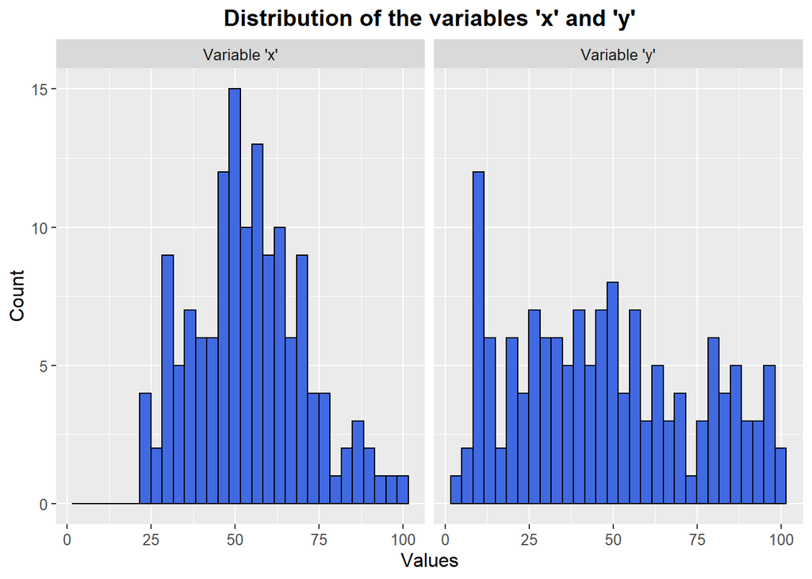

The question at this point is how would you describe the relationship between ‘x’ and ‘y’ without looking at a scatterplot?

### Show Solution

Not quite what you expected, right? This just serves as an example of why you must always check out the relationship between variables in a graph **BEFORE** you compute a correlation.

The data from this example was from the {datasauRus} package (don’t forget to install the package if you want to try this example out on your own).

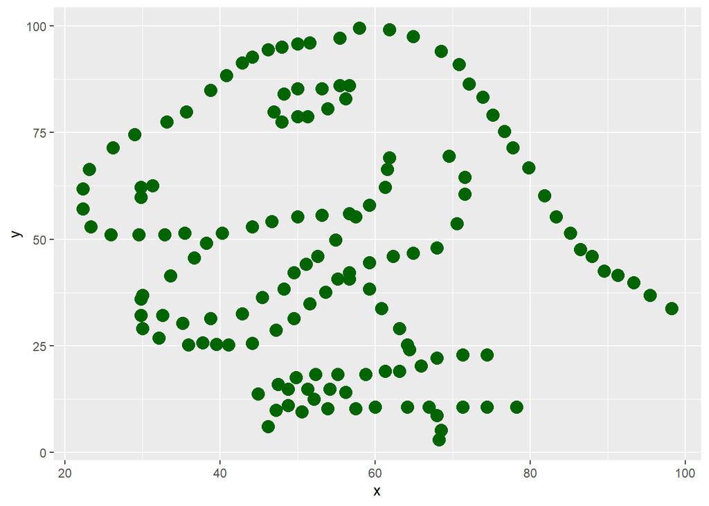

```r
# load the pacakge to get the access to the data
library(datasauRus)

# filter the data set for the "dino" values, and then ...
# generate a scatterplot

datasaurus_dozen %>%
  filter(dataset == "dino") %>%
  ggplot(aes(x = x, y = y)) +
  geom_point(size = 4,
             color = "darkgreen")
```

## Create/Import Data

As usual, the next step is to either load some data into R or create some data ourselves. For the exercises within this lab, we will load some data from the file “gradgpa.csv”[^1] (which should be inside the “data” folder within your R project).

```r
# import data
data_corr <- read_csv(file = here("data",
                            "gradgpa.csv"))
```

## Clean Up the Data

For data imported using the *readr* package, you can check whether there were any parsing problems using the `problems()` function.

```r
# check for parsing problems
# e.g., were there problems forcing a variable to be a certain type
problems(data_corr)
```

```
## # A tibble: 0 x 5
## # ... with 5 variables: row <int>, col <int>, expected <chr>, actual <chr>,
## #   file <chr>
```

It is always a good idea to `View()` your data **every** time you import it to ensure that the data look the way you expect. This is especially important if you have never seen the data before.

```r
# take a peak at the data
View(data_corr)
```

| ID | UndergradGPA | GREVerbal | GREQuant | Interview | GradGPA |
| --- | --- | --- | --- | --- | --- |
| 1 | 3.4 | 600 | 540 | 75 | 3.6 |
| 2 | 3.1 | 510 | 480 | 70 | 3.0 |
| 3 | 3.7 | 650 | 710 | 85 | 3.9 |
| 4 | 3.2 | 530 | 450 | 60 | 2.8 |
| 5 | 3.5 | 610 | 500 | 90 | 3.7 |
| 6 | 2.9 | 540 | 620 | 60 | 2.6 |
| 7 | 3.3 | 530 | 510 | 75 | 3.4 |
| 8 | 2.9 | 540 | 600 | 55 | 2.7 |
| 9 | 3.4 | 550 | 580 | 75 | 3.3 |
| 10 | 3.2 | 700 | 630 | 65 | 3.5 |

[output cut: 10 more lines]

Everything looks to be in order with regard to the types of variables in this data set.

## Check Out the Data

Before computing a correlation you should get to know your variables a bit first. A good place to start is to get some basic descriptive statistics and maybe a few plots (especially if you checked out the puzzle at the start of this exercise).

#### Descriptive Statistics

We will use the `describe()` function from the {psych} package to compute descriptive statistics. If you were checking out the variable names after we imported them above, you might have noticed a variable called `ID`. Computing summary statistics for this variable won’t tell us much beyond whether there were any missing values, so we can tell *R* to not use it using the `select()` function.

```r
# compute descriptive statistics for the data set
data_corr %>%
  select(-ID) %>%
  describe()
```

```
##              vars  n   mean    sd median trimmed   mad   min   max range  skew
## UndergradGPA    1 20   3.31  0.30   3.25    3.29  0.30   2.9   3.9   1.0  0.30
## GREVerbal       2 20 569.50 65.09 550.00  563.12 66.72 480.0 710.0 230.0  0.70
## GREQuant        3 20 563.50 74.92 545.00  558.12 81.54 450.0 710.0 260.0  0.42
## Interview       4 20  69.75  9.93  70.00   69.38 11.12  55.0  90.0  35.0  0.22
## GradGPA         5 20   3.21  0.44   3.25    3.22  0.52   2.4   3.9   1.5 -0.17
##              kurtosis    se
## UndergradGPA    -1.08  0.07
## GREVerbal       -0.52 14.55
## GREQuant        -1.00 16.75
## Interview       -1.04  2.22
## GradGPA         -1.36  0.10
```

### Check For Outliers

#### Box Plots

A box plot is one way to visually assess the distribution of a variable. A few things to look for when assessing a distribution for normality:

- The median is centred within the box (the inter-quartile)
- There are no outliers
- I colored the outliers red to make them stand out easier (if there are any at all)
- Both whiskers extend an appropriate amount beyond the upper and lower edges of the box.

There are five variables of interest in this data set, but for the sake of brevity I will only show the process for checking the correlation between `UndergradGPA` and `GradGPA`.

We could either create two seperate boxplots using code found in previous exercises, but today I want to tie together a few concepts we have used so far in this course.

I followed these steps to create the graph below:

1. Start with a data.frame/tibble
2. Create a subset of the variables I want to explore further
3. Convert the subset of data into long format so that all GPA values are in a single column (`GPA`) and the level of education is in another column (`edu_level`)
4. Use the mutate() function to change the values in newly created `edu_level` variable into values that will look better on the boxplot
5. Create a new ggplot() and add a geom_boxplot() layer  
   a. Fill each boxplot using the `edu_level`  
   b. Fill any outliers the color red to make them stand out
6. Remove the label from the x-axis as it is redundant and add a main title
7. Remove the legend as it is also redundant
8. Enlarge all text in the graph to size 12pt, then center and boldface the main title

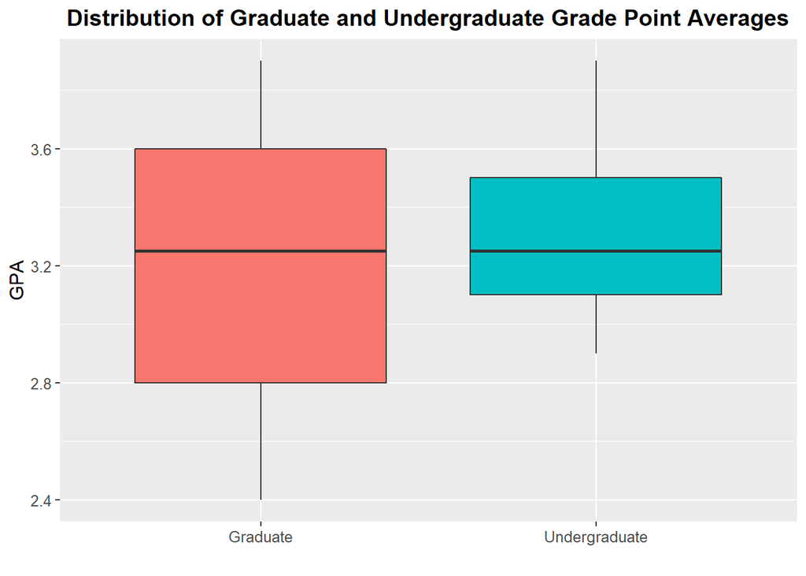

```r
# create a subset of variables we want to explore, and then ...
# convert to long format so that all GPA values are in a single column, and then ...
# Fix the names for better graphing, and then ...
# create a boxplot with the following feature:
# - enlarged text
# - center and bold the title
# - removed the legend
# - removed the x-axis title and added a main title

data_corr %>%
  select(UndergradGPA,GradGPA) %>%
  pivot_longer(cols = everything(),
               names_to = "edu_level",
               values_to = "GPA") %>%
  mutate(edu_level = case_when(
    edu_level == "GradGPA" ~ "Graduate",
    edu_level == "UndergradGPA" ~ "Undergraduate",
    TRUE ~ edu_level)) %>%
  ggplot(aes(x = edu_level,
             y = GPA)) +
  geom_boxplot(aes(fill = edu_level),
               outlier.fill = "red") +
  labs(x = "",
       title = "Distribution of Graduate and Undergraduate Grade Point Averages") +
  guides(fill = FALSE) +
  theme(text = element_text(size = 12),
        plot.title = element_text(hjust = .5, face = "bold"))
```

The plot above does not show the presence of any outliers for either variable.

### Linearity Between the Variables

It is important to check that the relationship is approximately linear between the variables. To do this we can construct a scatterplot using each of our two variables of interest on each axis. To help assess whether the relationship is approximately linear, a line showing the relationship can be added as another layer on this plot.

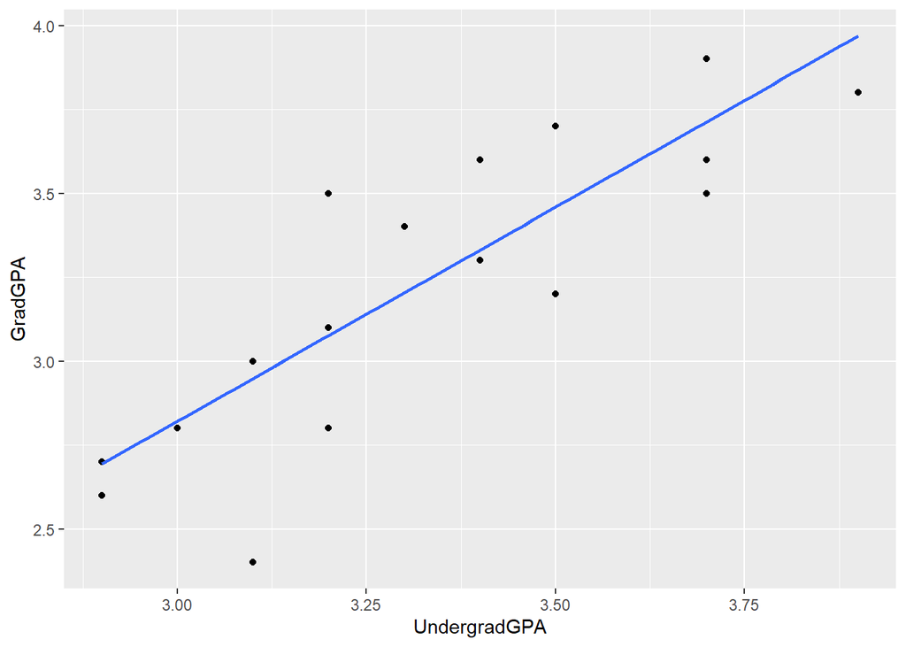

```r
# Use the original dataset and create a scatter plot with a "best-fitting" line
data_corr %>%
ggplot(aes(x = UndergradGPA,
           y = GradGPA)) +
  geom_point() +
  geom_smooth(method = "lm", se = FALSE)
```

Overall, the line seems to be doing a pretty good job in terms of representing the relationship between `UndergradGPA` and `GradGPA`.

## Compute Bivariate Correlation

Base *R* has a function for computing correlations (i.e., Pearson Product-Moment Correlations), `cor()`. It can accept either two continuous variables, or a whole data.frame/tibble.

```r
# compute a correlation between two variables, and then ...
# round all values to 2 digits
data_corr %>%
  select(UndergradGPA,GradGPA) %>%
  cor() %>%
  round(digits = 2)
```

|  | UndergradGPA | GradGPA |
| --- | --- | --- |
| UndergradGPA | 1.00 | 0.85 |
| GradGPA | 0.85 | 1.00 |

You can alter the code above to compute the correlations among all of the variables in the data.frame/tibble by removing the `select()` function.

If you are computing a correlation matrix, then you MUST first check all of the relationships visually for outliers and linearity.

## Compute a Partial Correlation

When computing a partial correlation you want to keep in mind which relationship you are interested in examining/testing. The relationship of interest is always between the variables *x* and *y* while controlling for the effect which a third variable (z) has on both of them.

So the following code tests the partial correlation between `UndergradGPA` and `GREQuant` while controlling for the effeect which `GradGPA` might have on both.

```r
# partial correlation
pcor.test(x = data_corr$UndergradGPA,
          y = data_corr$GREQuant,
          z = data_corr$GradGPA)
```

```
##    estimate   p.value statistic  n gp  Method
## 1 0.1170452 0.6332212 0.4859297 20  1 pearson
```

## Compute a Semi-Partial Correlation

When computing a semi-partial correlation you want to keep in mind which relationship you are interested in examining/testing. The relationship of interest is always between the variables *x* and *y* while controlling for the effect which a third variable (z) has on **only** *x*.

```r
# partial correlation
spcor.test(x = data_corr$UndergradGPA,
          y = data_corr$GREQuant,
          z = data_corr$GradGPA)
```

```
##     estimate   p.value statistic  n gp  Method
## 1 0.06079334 0.8047301 0.2511219 20  1 pearson
```

# Acknowledgements

- The lovely “DIV TIPS” were made using code from a fantastic blog entry by Desirée de leon at https://desiree.rbind.io/post/2019/making-tip-boxes-with-bookdown-and-rmarkdown/
- The copy to clipboard buttons were created using Klippy https://rlesur.github.io/klippy/reference/klippy.html
- The datasauRus was originally created by Alberto Cairo and showcased in his blog post http://www.thefunctionalart.com/2016/08/download-datasaurus-never-trust-summary.html

This work is licensed under a [Creative Commons Attribution-NonCommercial 4.0 International License](http://creativecommons.org/licenses/by-nc/4.0/).

[^1]: Adapted from pages 258-268 of Polit, D. F. (1996). Data analysis and statistics for nursing research. Stamford, CT: Appleton & Lange